# GenAI

Ellie Jeong

2023-11-05

## Data cleaning: 123 valid responses

## Descriptive statistics: frequency table, bar graph

### Demographics

*Q42 - What is your age?

```r
t_q42 <- datatable(survey_c %>%
                    group_by(Q42) %>%
                    tally() %>%
                    arrange(desc(n)) %>%
                    mutate(freq = round(n / sum(n),digits=2)))
t_q42
```

|  | Q42 | n | freq |
| --- | --- | --- | --- |
| 1 | 25-34 | 60 | 0.49 |
| 2 | 35-44 | 43 | 0.35 |
| 3 | 45-54 | 14 | 0.11 |
| 4 | 18-24 | 6 | 0.05 |

*Q43 - How do you identify your gender?

```r
t_q43 <- datatable(survey_c %>%
                    group_by(Q43) %>%
                    tally() %>%
                    arrange(desc(n)) %>%
                    mutate(freq = round(n / sum(n),digits=2)))
t_q43
```

|  | Q43 | n | freq |
| --- | --- | --- | --- |
| 1 | Man | 90 | 0.73 |
| 2 | Woman | 32 | 0.26 |
| 3 | Nonbinary | 1 | 0.01 |

```
*Q45 - How would you best describe your race/ethnicity?
```

```r
eth <- survey_c %>%
  separate_rows(Q45, sep = ",")
t_q45 <- datatable(eth %>%
                    group_by(Q45) %>%
                    tally() %>%
                    arrange(desc(n)) %>%
                    mutate(freq = round(n / sum(n),digits=2)))
t_q45
```

|  | Q45 | n | freq |
| --- | --- | --- | --- |
| 1 | White | 86 | 0.68 |
| 2 | Black or African American | 22 | 0.17 |
| 3 | Native Hawaiian or Other Pacific Islander | 8 | 0.06 |
| 4 | American Indian or Alaska Native | 5 | 0.04 |
| 5 | Asian | 5 | 0.04 |

```
*Q46 - What is your highest level of education?
```

```r
t_q46 <- datatable(survey_c %>%
                    group_by(Q46) %>%
                    tally() %>%
                    arrange(desc(n)) %>%
                    mutate(freq = round(n / sum(n),digits=2)))
t_q46
```

|  | Q46 | n | freq |
| --- | --- | --- | --- |
| 1 | Master's degree | 39 | 0.32 |
| 2 | Bachelor's degree | 35 | 0.28 |
| 3 | Doctorate | 26 | 0.21 |
| 4 | Associate degree | 10 | 0.08 |
| 5 | Technical or occupational certificate | 9 | 0.07 |
| 6 | High school diploma or equivalent | 3 | 0.02 |
| 7 | Prefer not to answer | 1 | 0.01 |

```
*Q4 - Are you currently located in the United States?
```

```r
t_q4 <- datatable(survey_c %>%
                    group_by(Q4) %>%
                    tally() %>%
                    arrange(desc(n)) %>%
                    mutate(freq = round(n / sum(n),digits=2)))
t_q4
```

|  | Q4 | n | freq |
| --- | --- | --- | --- |
| 1 | Yes | 122 | 0.99 |
| 2 | No | 1 | 0.01 |

```
*Q5 - Which of the following categories best describes your current employment status?
```

```r
t_q5 <- datatable(survey_c %>%
                    group_by(Q5) %>%
                    tally() %>%
                    arrange(desc(n)) %>%
                    mutate(freq = round(n / sum(n),digits=2)))
t_q5
```

|  | Q5 | n | freq |
| --- | --- | --- | --- |
| 1 | Employed full time (40 hours or more per week) | 102 | 0.83 |
| 2 | Employed part time (up to 39 hours per week) | 16 | 0.13 |
| 3 | Self-employed | 2 | 0.02 |
| 4 | Unemployed and currently looking for work | 2 | 0.02 |
| 5 | Student | 1 | 0.01 |

```
*Q6 - How would you classify your most recent Computer and Information Technology
```

job? (check all that apply)

```r
job <- survey_c %>%
  separate_rows(Q6, sep = ",")
t_q6 <- datatable(job %>%
                    group_by(Q6) %>%
                    tally() %>%
                    arrange(desc(n)) %>%
                    mutate(freq = round(n / sum(n),digits=2)))
t_q6
```

|  | Q6 | n | freq |
| --- | --- | --- | --- |
| 1 | Software/Web Developers | 76 | 0.22 |
| 2 | Computer Programmers | 60 | 0.17 |
| 3 | Software Testers | 42 | 0.12 |
| 4 | Software Quality Assurance Analysts | 36 | 0.1 |
| 5 | Computer Network Architects | 28 | 0.08 |
| 6 | Computer Systems Analysts | 26 | 0.08 |
| 7 | Computer and Information Research Scientists | 25 | 0.07 |
| 8 | Information Security Analysts | 16 | 0.05 |
| 9 | Computer Support Specialists | 12 | 0.03 |
| 10 | Network and Computer Systems Administrators | 11 | 0.03 |

[output cut: 2 more lines]

```
*Q11 - How would you classify the industry where you worked most recently as a software
```

engineer? (check all that apply)

```r
industry <- survey_c %>%
  separate_rows(Q11, sep = ",")
t_q11 <- datatable(industry %>%
                    group_by(Q11) %>%
                    tally() %>%
                    arrange(desc(n)) %>%
                    mutate(freq = round(n / sum(n),digits=2)))
t_q11
```

|  | Q11 | n | freq |
| --- | --- | --- | --- |
| 1 | Computer and Information Technology | 61 | 0.41 |
| 2 | Business and Financial | 6 | 0.04 |
| 3 | Training | 5 | 0.03 |
| 4 | and Library | 5 | 0.03 |
| 5 | Education | 5 | 0.03 |
| 6 | Management | 5 | 0.03 |
| 7 | Media and Communication | 5 | 0.03 |
| 8 | Production | 5 | 0.03 |
| 9 | Fishing | 4 | 0.03 |
| 10 | and Forestry | 4 | 0.03 |

[output cut: 20 more lines]

### Usage patterns

```
*Q18 - How often do/did you use GenAI tools for software engineering work?
```

```r
t_q18 <- datatable(survey_c %>%
                    group_by(Q18) %>%
                    tally() %>%
                    arrange(desc(n)) %>%
                    mutate(freq = round(n / sum(n),digits=2)))
t_q18
```

|  | Q18 | n | freq |
| --- | --- | --- | --- |
| 1 | Everyday | 69 | 0.56 |
| 2 | Several times a week | 44 | 0.36 |
| 3 | Once a week | 8 | 0.07 |
| 4 | Once a month | 1 | 0.01 |
| 5 |  | 1 | 0.01 |

*Q12- How long have you worked as a software engineer?

```r
t_q12 <- datatable(survey_c %>%
                    group_by(Q12) %>%
                    tally() %>%
                    arrange(desc(n)) %>%
                    mutate(freq = round(n / sum(n),digits=2)))
t_q12
```

|  | Q12 | n | freq |
| --- | --- | --- | --- |
| 1 | 1-5 years | 66 | 0.54 |
| 2 | 6-10 years | 34 | 0.28 |
| 3 | 11-15 years | 17 | 0.14 |
| 4 | Less than one year | 3 | 0.02 |
| 5 | More than 15 years | 3 | 0.02 |

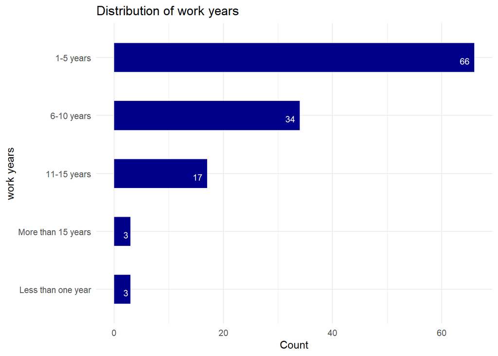

```r
# Create a data frame for charts
df_q12 <- survey_c %>%
  group_by(Q12) %>%
  summarise(freq = n()) %>%
  arrange(desc(freq)) %>%
  mutate(percent = round(freq / sum(freq),digits = 2))

#bar grahp
b_q12 <- ggplot(data = df_q12, aes(x = reorder(Q12, freq), y = freq)) +
  geom_bar(stat = "identity", width = 0.5, fill = "darkblue") +
  theme_minimal() +
  labs(title = "Distribution of work years", x = "work years", y = "Count") +
  geom_text(aes(label = freq), color = "white", vjust = 1, hjust = 1.5, size = 3) +
  scale_fill_manual(values = "darkblue") +
  theme(legend.position = "none") +
  coord_flip() + scale_fill_aaas()  + theme(legend.position="none")
b_q12
```

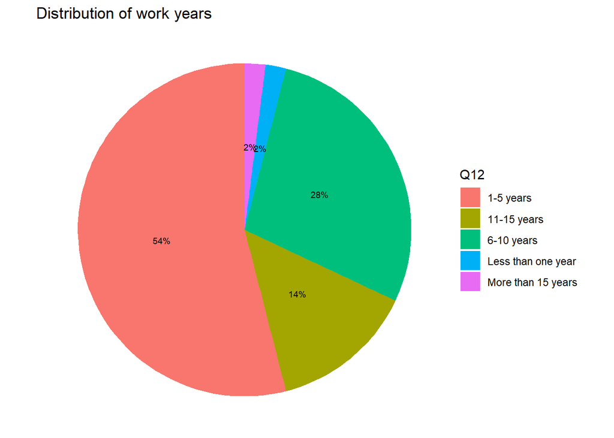

```r
# Create the pie chart
p_q12 <- ggplot(data = df_q12, aes(x = "", y = percent, fill = Q12)) +
  geom_bar(stat = "identity", width = 1) +
  coord_polar(theta = "y") +
  labs(title = "Distribution of work years") +
  theme_void() +
  geom_text(aes(label = paste0(round(percent*100), '%')),
            position = position_stack(vjust = 0.5), size = 2.5)

p_q12
```

*Q13 - Which of the following tasks best describes the activities that you do/did in your role as a software engineer?

```r
task <- survey_c %>%
  separate_rows(Q13, sep = ",")
t_Q13 <- datatable(task %>%
                    group_by(Q13) %>%
                    tally() %>%
                    arrange(desc(n)) %>%
                    mutate(freq = round(n / sum(n),digits=2)))
t_Q13
```

|  | Q13 | n | freq |
| --- | --- | --- | --- |
| 1 | Writing code | 84 | 0.16 |
| 2 | Testing new software programs | 76 | 0.14 |
| 3 | Optimizing software for speed and scalability | 70 | 0.13 |
| 4 | Testing and evaluating code | 66 | 0.12 |
| 5 | Designing software systems | 65 | 0.12 |
| 6 | Maintaining software systems | 63 | 0.12 |
| 7 | Evaluating software programs | 60 | 0.11 |
| 8 | Document aspects of an application or system as a reference | 55 | 0.1 |

*Q16- Have you used GenAI?

```r
# Q16- have you used GenAI?
##frequency table
use_t <- table(survey_c$Q16)
use_t <- sort(use_t, decreasing = FALSE)

##Datatable
t_Q16 <- datatable(survey_c %>%
                    group_by(Q16) %>%
                    tally() %>%
                    arrange(desc(n)) %>%
                    mutate(freq = round(n / sum(n),digits=2)))
t_Q16
```

|  | Q16 | n | freq |
| --- | --- | --- | --- |
| 1 | Yes | 122 | 0.99 |
| 2 | No | 1 | 0.01 |

*Q17-What GenAI tools have you used for software engineering work? (check all that apply)

```r
tool <- survey_c %>%
  separate_rows(Q17, sep = ",")  # Adjust the separator to match your data
tool_t <- table(tool$Q17)
tool_t <- sort(tool_t, decreasing = FALSE)


##Datatable
t_Q17 <- datatable(tool %>%
                    group_by(Q17) %>%
                    tally() %>%
                    arrange(desc(n)) %>%
                    mutate(freq = round(n / sum(n),digits=2)))
t_Q17
```

|  | Q17 | n | freq |
| --- | --- | --- | --- |
| 1 | ChatGPT | 92 | 0.13 |
| 2 | Bing A.I | 68 | 0.1 |
| 3 | Bard | 64 | 0.09 |
| 4 | GitHub CoPilot | 62 | 0.09 |
| 5 | Sketch2Code | 49 | 0.07 |
| 6 | StarCoder | 49 | 0.07 |
| 7 | DeepCode | 47 | 0.07 |
| 8 | Anthropic Claude | 45 | 0.07 |
| 9 | Codewhisperer | 45 | 0.07 |
| 10 | Codey | 45 | 0.07 |

[output cut: 4 more lines]

```
*Q22 - What GenAI tools have you used to attain knowledge and skills for software
```

engineering work? (check all that apply)

```r
tool <- survey_c %>%
  separate_rows(Q22, sep = ",")
t_q22 <- datatable(tool %>%
                    group_by(Q22) %>%
                    tally() %>%
                    arrange(desc(n)) %>%
                    mutate(freq = round(n / sum(n),digits=2)))
t_q22
```

|  | Q22 | n | freq |
| --- | --- | --- | --- |
| 1 | ChatGPT | 71 | 0.13 |
| 2 | Bard | 52 | 0.09 |
| 3 | Bing A.I | 50 | 0.09 |
| 4 | Anthropic Claude | 37 | 0.07 |
| 5 | TensorFlow | 37 | 0.07 |
| 6 | GitHub CoPilot | 36 | 0.07 |
| 7 | Sketch2Code | 36 | 0.07 |
| 8 |  | 36 | 0.07 |
| 9 | Codey | 34 | 0.06 |
| 10 | StarCoder | 34 | 0.06 |

[output cut: 4 more lines]

*Q19-What are/were your purposes for using GenAI tools in software engineering work? (check all that apply)

```r
aim <- survey_c %>%
  separate_rows(Q19, sep = ",")  # Adjust the separator to match your data

##Datatable
t_Q19 <- datatable(aim %>%
                    group_by(Q19) %>%
                    tally() %>%
                    arrange(desc(n)) %>%
                    mutate(freq = round(n / sum(n),digits=2)))
t_Q19
```

|  | Q19 | n | freq |
| --- | --- | --- | --- |
| 1 | Self-evaluating performances | 76 | 0.14 |
| 2 | Tackling new challenges | 71 | 0.13 |
| 3 | Starting work and getting in the flow of work quickly | 70 | 0.13 |
| 4 | Completing manual and repetitive work | 68 | 0.13 |
| 5 | Developing skills | 68 | 0.13 |
| 6 | Short-term problem-solving | 66 | 0.12 |
| 7 | Co-operating and interacting with colleagues | 58 | 0.11 |
| 8 | Long-term problem-solving | 57 | 0.11 |
| 9 | Other | 1 | 0 |
| 10 |  | 1 | 0 |

*Q20- How do you think the GenAI tools help you with software engineering work? (check all that apply

```r
benefit <- survey_c %>%
  separate_rows(Q20, sep = ",")  # Adjust the separator to match your data

##Datatable
t_Q20 <- datatable(benefit %>%
                    group_by(Q20) %>%
                    tally() %>%
                    arrange(desc(n)) %>%
                    mutate(freq = round(n / sum(n),digits=2)))
t_Q20
```

|  | Q20 | n | freq |
| --- | --- | --- | --- |
| 1 | I can attain knowledge and skills | 87 | 0.25 |
| 2 | I can improve quality of work | 65 | 0.18 |
| 3 | I can complete my work faster | 63 | 0.18 |
| 4 | I can enjoy my work more | 50 | 0.14 |
| 5 | I feel socially connected and supported | 48 | 0.14 |
| 6 | I can focus on the higher level of work instead of mundane and repetitive work | 41 | 0.12 |
| 7 |  | 1 | 0 |

*Q21 - In the previous question you indicated that “I can attain knowledge and skills” when using GenAI tools. In what practices do you want to use GenAI tools for the purpose of attaining knowledge and skills for software engineering? (check all that apply)

```r
practice <- survey_c %>%
  separate_rows(Q21, sep = ",")  # Adjust the separator to match your data

##Datatable
t_Q21 <- datatable(practice %>%
                    group_by(Q21) %>%
                    tally() %>%
                    arrange(desc(n)) %>%
                    mutate(freq = round(n / sum(n),digits=2)))
t_Q21
```

|  | Q21 | n | freq |
| --- | --- | --- | --- |
| 1 | Writing code | 64 | 0.12 |
| 2 | Testing new software programs | 57 | 0.11 |
| 3 | Optimizing software for speed and scalability | 55 | 0.11 |
| 4 | Maintaining software systems | 54 | 0.1 |
| 5 | refactoring) | 52 | 0.1 |
| 6 | Evaluating software programs | 52 | 0.1 |
| 7 | Testing and evaluating code (e.g. | 52 | 0.1 |
| 8 | Designing software systems | 50 | 0.1 |
| 9 | Document aspects of an application or system as a reference | 46 | 0.09 |
| 10 |  | 36 | 0.07 |

*Q23 - In the previous question you indicated that “I can attain knowledge and skills” when using GenAI tools. What kind of knowledge and skills for software engineering work do you want to learn through the GenAI tools? (check all that apply)

```r
skill <- survey_c %>%
  separate_rows(Q23, sep = ",")  # Adjust the separator to match your data

##Datatable
t_Q23 <- datatable(skill %>%
                    group_by(Q23) %>%
                    tally() %>%
                    arrange(desc(n)) %>%
                    mutate(freq = round(n / sum(n),digits=2)))
t_Q23
```

|  | Q23 | n | freq |
| --- | --- | --- | --- |
| 1 | Tools and technologies for task performance | 63 | 0.16 |
| 2 | Knowledge of the field | 62 | 0.16 |
| 3 | Understanding issues and their contexts | 61 | 0.16 |
| 4 | Decision-making and problem-solving | 60 | 0.16 |
| 5 | Personal development | 53 | 0.14 |
| 6 | Working with others | 49 | 0.13 |
| 7 |  | 36 | 0.09 |

*Q24 - In the previous question you did not indicate “I can attain knowledge and skills”when using GenAI tools. Have you ever felt the need to attain knowledge and skills for software engineering work?

```r
t_Q24 <- datatable(survey_c %>%
                    group_by(Q24) %>%
                    tally() %>%
                    arrange(desc(n)) %>%
                    mutate(freq = round(n / sum(n),digits=2)))
t_Q24
```

|  | Q24 | n | freq |
| --- | --- | --- | --- |
| 1 |  | 88 | 0.72 |
| 2 | Yes | 34 | 0.28 |
| 3 | No | 1 | 0.01 |

*Q25 - For what practices do you feel the need to attain knowledge and skills for software engineering work? (check all that apply)

```r
practice_2 <- survey_c %>%
  separate_rows(Q25, sep = ",")  # Adjust the separator to match your data

##Datatable
t_Q25 <- datatable(practice_2 %>%
                    group_by(Q25) %>%
                    tally() %>%
                    arrange(desc(n)) %>%
                    mutate(freq = round(n / sum(n),digits=2)))
t_Q25
```

|  | Q25 | n | freq |
| --- | --- | --- | --- |
| 1 |  | 89 | 0.4 |
| 2 | Writing code | 20 | 0.09 |
| 3 | Testing new software programs | 18 | 0.08 |
| 4 | Evaluating software programs | 16 | 0.07 |
| 5 | Maintaining software systems | 16 | 0.07 |
| 6 | refactoring) | 14 | 0.06 |
| 7 | Testing and evaluating code (e.g. | 14 | 0.06 |
| 8 | Optimizing software for speed and scalability | 13 | 0.06 |
| 9 | Document aspects of an application or system as a reference | 12 | 0.05 |
| 10 | Designing software systems | 10 | 0.04 |

[output cut: 1 more lines]

*Q26 - What kind of knowledge and skills do you feel the need to learn for software engineering work? (check all that apply)

```r
skill_2 <- survey_c %>%
  separate_rows(Q26, sep = ",")  # Adjust the separator to match your data

##Datatable
t_Q26 <- datatable(skill_2 %>%
                    group_by(Q26) %>%
                    tally() %>%
                    arrange(desc(n)) %>%
                    mutate(freq = round(n / sum(n),digits=2)))
t_Q26
```

|  | Q26 | n | freq |
| --- | --- | --- | --- |
| 1 |  | 89 | 0.47 |
| 2 | Decision-making and problem-solving | 22 | 0.12 |
| 3 | Knowledge of the field | 19 | 0.1 |
| 4 | Tools and technologies for task performance | 16 | 0.08 |
| 5 | Understanding issues and their contexts | 16 | 0.08 |
| 6 | Personal development | 14 | 0.07 |
| 7 | Working with others | 14 | 0.07 |

- Q33 - Rate the level of importance of each of following items when considering the use of GenAI tools in learning (e.g., attaining knowledge and skills) during software engineering work (1: not important at all, 5: very important).

```r
# List of column names you want to convert to numeric
columns_to_convert <- c("Q33_1", "Q33_2", "Q33_3", "Q33_4", "Q33_5", "Q33_6", "Q33_7", "Q33_8", "Q33_9", "Q33_10", "Q33_11")
survey_c <- survey_c %>%
  mutate_at(vars(all_of(columns_to_convert)), as.numeric)

summary_stats <- sapply(survey_c[, columns_to_convert], function(x) c(
  round(min(x), digits = 2),
  round(max(x), digits = 2),
  round(mean(x), digits = 2),
  round(sd(x), digits = 2),
  round(var(x), digits = 2)
))
summary_stats <- as.data.frame(summary_stats)
col_stat <- c("Accountability","Reliability","Transparency","Fairness", "Privacy","Security","Safety","Autonomy","Flexibility","Accessibility","Customization")
colnames(summary_stats) <- col_stat
row_stat <- c("Min","Max","Mean","StandardDeviation","Variance")
rownames(summary_stats) <- row_stat
datatable(summary_stats)
```

|  | Accountability | Reliability | Transparency | Fairness | Privacy | Security | Safety | Autonomy | Flexibility | Accessibility | Customization |
| --- | --- | --- | --- | --- | --- | --- | --- | --- | --- | --- | --- |
| Min | 1 | 2 | 1 | 2 | 2 | 2 | 1 | 1 | 2 | 1 | 1 |
| Max | 5 | 5 | 5 | 5 | 5 | 5 | 5 | 5 | 5 | 5 | 5 |
| Mean | 4.03 | 3.97 | 3.89 | 3.97 | 4.01 | 4.03 | 3.98 | 3.93 | 3.95 | 3.93 | 3.89 |
| StandardDeviation | 0.78 | 0.83 | 0.86 | 0.81 | 0.83 | 0.82 | 0.87 | 0.87 | 0.74 | 0.82 | 0.84 |
| Variance | 0.61 | 0.69 | 0.74 | 0.65 | 0.7 | 0.67 | 0.76 | 0.76 | 0.55 | 0.67 | 0.71 |

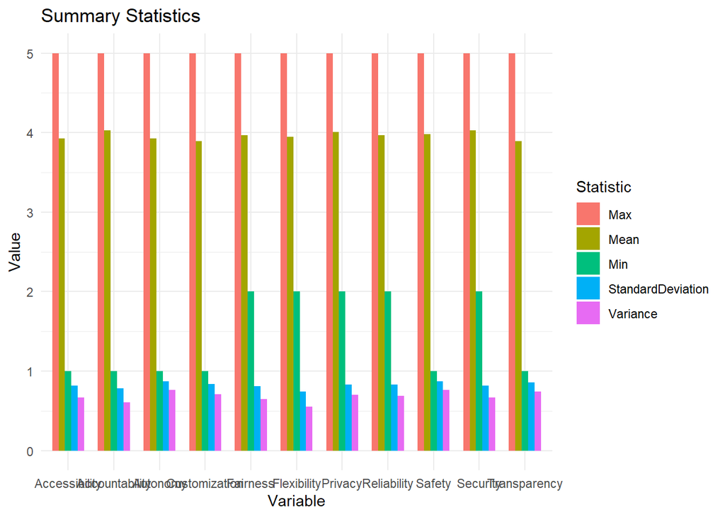

```r
# Reshape the data into a long format
summary_stats_long <- summary_stats %>%
  rownames_to_column(var = "Statistic") %>%
  pivot_longer(cols = -Statistic, names_to = "Variable", values_to = "Value")

# Create a grouped bar graph
grouped_bar <- ggplot(summary_stats_long, aes(x = Variable, y = Value, fill = Statistic)) +
  geom_bar(stat = "identity", position = "dodge", width = 0.7) +
  labs(title = "Summary Statistics",
       x = "Variable",
       y = "Value") +
  theme_minimal()
grouped_bar
```

- Q36 - When do you want the GenAI tools to assist you in learning knowledge and skills for software engineering work? (check all that apply)

```r
q36 <- survey_c %>%
  separate_rows(Q36, sep = ",")  # Adjust the separator to match your data

##Datatable
t_q36 <- datatable(q36 %>%
                    group_by(Q36) %>%
                    tally() %>%
                    arrange(desc(n)) %>%
                    mutate(freq = round(n / sum(n),digits=2)))
t_q36
```

|  | Q36 | n | freq |
| --- | --- | --- | --- |
| 1 | Before an action | 70 | 0.31 |
| 2 | During an action | 69 | 0.31 |
| 3 | After an action | 54 | 0.24 |
| 4 | When you need specific assistance | 30 | 0.13 |
| 5 | Other | 1 | 0 |

- Q37 - How do you want the GenAI tools to assist you in learning knowledge and skills for software engineering work? (check all that apply)

```r
q37 <- survey_c %>%
  separate_rows(Q37, sep = ",")  # Adjust the separator to match your data

##Datatable
t_q37 <- datatable(q37 %>%
                    group_by(Q37) %>%
                    tally() %>%
                    arrange(desc(n)) %>%
                    mutate(freq = round(n / sum(n),digits=2)))
t_q37
```

|  | Q37 | n | freq |
| --- | --- | --- | --- |
| 1 | Textually | 86 | 0.42 |
| 2 | Visually | 78 | 0.38 |
| 3 | Acoustically | 42 | 0.2 |

- Q38 - Where do you want the GenAI tools to offer assistance for learning knowledge and skills for software engineering work? (e.g., information wrapped in tooltips)? (check all that apply)

```r
q38 <- survey_c %>%
  separate_rows(Q38, sep = ",")  # Adjust the separator to match your data

##Datatable
t_q38 <- datatable(q38 %>%
                    group_by(Q38) %>%
                    tally() %>%
                    arrange(desc(n)) %>%
                    mutate(freq = round(n / sum(n),digits=2)))
t_q38
```

|  | Q38 | n | freq |
| --- | --- | --- | --- |
| 1 | Document sidebars | 83 | 0.21 |
| 2 | Tables | 76 | 0.2 |
| 3 | Pop-ups | 69 | 0.18 |
| 4 | Tooltips | 60 | 0.16 |
| 5 | Visual effects | 53 | 0.14 |
| 6 | Sound effects | 45 | 0.12 |
| 7 | Others | 1 | 0 |

- Q39 - Which aspects of learning for software engineering work can be improved more by the assistance of GenAI? (check all that apply)

```r
q39 <- survey_c %>%
  separate_rows(Q39, sep = ",")  # Adjust the separator to match your data

##Datatable
t_q39 <- datatable(q39 %>%
                    group_by(Q39) %>%
                    tally() %>%
                    arrange(desc(n)) %>%
                    mutate(freq = round(n / sum(n),digits=2)))
t_q39
```

|  | Q39 | n | freq |
| --- | --- | --- | --- |
| 1 | Knowledge of the field | 68 | 0.19 |
| 2 | Using effective tools and technologies for task performance | 68 | 0.19 |
| 3 | Understanding issues and their contexts | 63 | 0.17 |
| 4 | Personal development | 58 | 0.16 |
| 5 | Working with others | 57 | 0.16 |
| 6 | Decision-making and problem-solving | 48 | 0.13 |

```r
# #Chi-square test
# eth_timing <- chisq.test(survey_c$Q45, survey_c$Q36, correct=FALSE)
# # printing the p-value
# eth_timing$p.value
# # printing the mean
# eth_timing$estimate
#
# #Fisher's exact test (Fisher’s exact test is used when there is at least one cell in the contingency table of the expected frequencies below 5)
# #https://statsandr.com/blog/fisher-s-exact-test-in-r-independence-test-for-a-small-sample/
# test <- fisher.test(dataframe)
```